# 254312501 - Selahattin KOÇ

**Yapay Sinir Ağları**

Üsküdar Üniversitesi, Yapay Zeka Mühendisliği Yüksek Lisans (Tezli)

**GitHub :** https://github.com/tcsekoc/YSA

```python
# Temel kütüphaneler
import numpy as np
import pandas as pd

# Görselleştirme kütüphaneleri
import matplotlib.pyplot as plt
import seaborn as sns

# Grafiklerin not defterinde görünmesi için
%matplotlib inline

# Görsel stil (isteğe bağlı, daha okunaklı grafikler)
sns.set(style="whitegrid", font_scale=1.0)
```

```python
from google.colab import files

uploaded = files.upload()
```

Upload widget is only available when the cell has been executed in the current browser session. Please rerun this cell to enable.

```
Saving breast_cancer_wisconsin.csv to breast_cancer_wisconsin.csv
```

```python
import pandas as pd

# Dosya adını otomatik olarak algılayalım
file_name = list(uploaded.keys())[0]
print("Yüklenen dosya adı:", file_name)

# CSV'yi oku
df = pd.read_csv(file_name)

# İlk 5 satırı görüntüle
print("Veri setinin ilk 5 satırı:")
display(df.head())

# Hedef sütun adı
target_column = "target"  # Dosyanda farklıysa burayı güncelleriz

# X - y ayrımı
X = df.drop(columns=[target_column])
y = df[target_column]

print("\nX şekli:", X.shape)
print("y şekli:", y.shape)
```

```
Yüklenen dosya adı: breast_cancer_wisconsin.csv
Veri setinin ilk 5 satırı:
```

|  | mean radius | mean texture | mean perimeter | mean area | mean smoothness | mean compactness | mean concavity | mean concave points | mean symmetry | mean fractal dimension | ... | worst texture | worst perimeter | worst area | worst smoothness | worst compactness | worst concavity | worst concave points | worst symmetry | worst fractal dimension | target |
| --- | --- | --- | --- | --- | --- | --- | --- | --- | --- | --- | --- | --- | --- | --- | --- | --- | --- | --- | --- | --- | --- |
| 0 | 17.99 | 10.38 | 122.80 | 1001.0 | 0.11840 | 0.27760 | 0.3001 | 0.14710 | 0.2419 | 0.07871 | ... | 17.33 | 184.60 | 2019.0 | 0.1622 | 0.6656 | 0.7119 | 0.2654 | 0.4601 | 0.11890 | 0 |
| 1 | 20.57 | 17.77 | 132.90 | 1326.0 | 0.08474 | 0.07864 | 0.0869 | 0.07017 | 0.1812 | 0.05667 | ... | 23.41 | 158.80 | 1956.0 | 0.1238 | 0.1866 | 0.2416 | 0.1860 | 0.2750 | 0.08902 | 0 |
| 2 | 19.69 | 21.25 | 130.00 | 1203.0 | 0.10960 | 0.15990 | 0.1974 | 0.12790 | 0.2069 | 0.05999 | ... | 25.53 | 152.50 | 1709.0 | 0.1444 | 0.4245 | 0.4504 | 0.2430 | 0.3613 | 0.08758 | 0 |
| 3 | 11.42 | 20.38 | 77.58 | 386.1 | 0.14250 | 0.28390 | 0.2414 | 0.10520 | 0.2597 | 0.09744 | ... | 26.50 | 98.87 | 567.7 | 0.2098 | 0.8663 | 0.6869 | 0.2575 | 0.6638 | 0.17300 | 0 |
| 4 | 20.29 | 14.34 | 135.10 | 1297.0 | 0.10030 | 0.13280 | 0.1980 | 0.10430 | 0.1809 | 0.05883 | ... | 16.67 | 152.20 | 1575.0 | 0.1374 | 0.2050 | 0.4000 | 0.1625 | 0.2364 | 0.07678 | 0 |

5 rows × 31 columns

```
X şekli: (569, 30)
y şekli: (569,)
```

```python
# 2.1 Eksik Değer Analizi

print("Her sütundaki eksik değer (missing value) sayıları:\n")
missing_per_column = df.isnull().sum()
print(missing_per_column)

print("\nToplam eksik değer sayısı:", int(missing_per_column.sum()))

from sklearn.impute import SimpleImputer

if missing_per_column.sum() > 0:
    print("\nEksik değerler tespit edildi. Median (ortanca) ile dolduruluyor...")

    imputer = SimpleImputer(strategy="median")
    X_imputed = imputer.fit_transform(X)
    X = pd.DataFrame(X_imputed, columns=X.columns)

    df = X.copy()
    df["target"] = y.values

    print("Eksik değer doldurma işlemi tamamlandı.")
else:
    print("\nEksik değer bulunamadı, doldurma işlemine gerek yok.")
```

```
Her sütundaki eksik değer (missing value) sayıları:

mean radius                0
mean texture               0
mean perimeter             0
mean area                  0
mean smoothness            0
mean compactness           0
mean concavity             0
mean concave points        0
mean symmetry              0
mean fractal dimension     0
radius error               0
texture error              0
perimeter error            0
area error                 0
smoothness error           0
compactness error          0
concavity error            0
concave points error       0
symmetry error             0
fractal dimension error    0
worst radius               0
worst texture              0
worst perimeter            0
worst area                 0
worst smoothness           0
worst compactness          0
worst concavity            0
worst concave points       0
worst symmetry             0
worst fractal dimension    0
target                     0
dtype: int64

Toplam eksik değer sayısı: 0

Eksik değer bulunamadı, doldurma işlemine gerek yok.
```

```python
# 2.2 Aykırı Değer Analizi (IQR)

import numpy as np

Q1 = X.quantile(0.25)
Q3 = X.quantile(0.75)
IQR = Q3 - Q1

lower_bound = Q1 - 1.5 * IQR
upper_bound = Q3 + 1.5 * IQR

outlier_mask = (X < lower_bound) | (X > upper_bound)
outlier_counts = outlier_mask.sum()

print("Her özellik için aykırı değer sayıları:\n")
print(outlier_counts)

print("\nToplam aykırı değer sayısı:", int(outlier_counts.sum()))
```

```
Her özellik için aykırı değer sayıları:

mean radius                14
mean texture                7
mean perimeter             13
mean area                  25
mean smoothness             6
mean compactness           16
mean concavity             18
mean concave points        10
mean symmetry              15
mean fractal dimension     15
radius error               38
texture error              20
perimeter error            38
area error                 65
smoothness error           30
compactness error          28
concavity error            22
concave points error       19
symmetry error             27
fractal dimension error    28
worst radius               17
worst texture               5
worst perimeter            15
worst area                 35
worst smoothness            7
worst compactness          16
worst concavity            12
worst concave points        0
worst symmetry             23
worst fractal dimension    24
dtype: int64

Toplam aykırı değer sayısı: 608
```

```python
# 2.3 Veri Tipi ve Dağılım İncelemesi

print("Sütun veri tipleri (dtypes):\n")
print(df.dtypes)

numeric_cols = df.select_dtypes(include=["int64", "float64"]).columns
categorical_cols = df.select_dtypes(exclude=["int64", "float64"]).columns

print("\nSayısal değişken sayısı:", len(numeric_cols))
print("Sayısal değişkenler:", list(numeric_cols))

print("\nKategorik değişken sayısı:", len(categorical_cols))
print("Kategorik değişkenler:", list(categorical_cols))
```

```
Sütun veri tipleri (dtypes):

mean radius                float64
mean texture               float64
mean perimeter             float64
mean area                  float64
mean smoothness            float64
mean compactness           float64
mean concavity             float64
mean concave points        float64
mean symmetry              float64
mean fractal dimension     float64
radius error               float64
texture error              float64
perimeter error            float64
area error                 float64
smoothness error           float64
compactness error          float64
concavity error            float64
concave points error       float64
symmetry error             float64
fractal dimension error    float64
worst radius               float64
worst texture              float64
worst perimeter            float64
worst area                 float64
worst smoothness           float64
worst compactness          float64
worst concavity            float64
worst concave points       float64
worst symmetry             float64
worst fractal dimension    float64
target                       int64
dtype: object

Sayısal değişken sayısı: 31
Sayısal değişkenler: ['mean radius', 'mean texture', 'mean perimeter', 'mean area', 'mean smoothness', 'mean compactness', 'mean concavity', 'mean concave points', 'mean symmetry', 'mean fractal dimension', 'radius error', 'texture error', 'perimeter error', 'area error', 'smoothness error', 'compac…

Kategorik değişken sayısı: 0
Kategorik değişkenler: []
```

```python
# 3.1 İstatistiksel Özellikler

stats = X.describe().T
stats["median"] = X.median()
stats["Q1"] = X.quantile(0.25)
stats["Q3"] = X.quantile(0.75)

stats_selected = stats[["mean", "median", "min", "max", "std", "Q1", "Q3"]]

print("Her özellik için istatistiksel özet:\n")
display(stats_selected)
```

```
Her özellik için istatistiksel özet:
```

|  | mean | median | min | max | std | Q1 | Q3 |
| --- | --- | --- | --- | --- | --- | --- | --- |
| mean radius | 14.127292 | 13.370000 | 6.981000 | 28.11000 | 3.524049 | 11.700000 | 15.780000 |
| mean texture | 19.289649 | 18.840000 | 9.710000 | 39.28000 | 4.301036 | 16.170000 | 21.800000 |
| mean perimeter | 91.969033 | 86.240000 | 43.790000 | 188.50000 | 24.298981 | 75.170000 | 104.100000 |
| mean area | 654.889104 | 551.100000 | 143.500000 | 2501.00000 | 351.914129 | 420.300000 | 782.700000 |
| mean smoothness | 0.096360 | 0.095870 | 0.052630 | 0.16340 | 0.014064 | 0.086370 | 0.105300 |
| mean compactness | 0.104341 | 0.092630 | 0.019380 | 0.34540 | 0.052813 | 0.064920 | 0.130400 |
| mean concavity | 0.088799 | 0.061540 | 0.000000 | 0.42680 | 0.079720 | 0.029560 | 0.130700 |
| mean concave points | 0.048919 | 0.033500 | 0.000000 | 0.20120 | 0.038803 | 0.020310 | 0.074000 |
| mean symmetry | 0.181162 | 0.179200 | 0.106000 | 0.30400 | 0.027414 | 0.161900 | 0.195700 |
| mean fractal dimension | 0.062798 | 0.061540 | 0.049960 | 0.09744 | 0.007060 | 0.057700 | 0.066120 |
| radius error | 0.405172 | 0.324200 | 0.111500 | 2.87300 | 0.277313 | 0.232400 | 0.478900 |
| texture error | 1.216853 | 1.108000 | 0.360200 | 4.88500 | 0.551648 | 0.833900 | 1.474000 |
| perimeter error | 2.866059 | 2.287000 | 0.757000 | 21.98000 | 2.021855 | 1.606000 | 3.357000 |
| area error | 40.337079 | 24.530000 | 6.802000 | 542.20000 | 45.491006 | 17.850000 | 45.190000 |
| smoothness error | 0.007041 | 0.006380 | 0.001713 | 0.03113 | 0.003003 | 0.005169 | 0.008146 |
| compactness error | 0.025478 | 0.020450 | 0.002252 | 0.13540 | 0.017908 | 0.013080 | 0.032450 |
| concavity error | 0.031894 | 0.025890 | 0.000000 | 0.39600 | 0.030186 | 0.015090 | 0.042050 |
| concave points error | 0.011796 | 0.010930 | 0.000000 | 0.05279 | 0.006170 | 0.007638 | 0.014710 |
| symmetry error | 0.020542 | 0.018730 | 0.007882 | 0.07895 | 0.008266 | 0.015160 | 0.023480 |
| fractal dimension error | 0.003795 | 0.003187 | 0.000895 | 0.02984 | 0.002646 | 0.002248 | 0.004558 |
| worst radius | 16.269190 | 14.970000 | 7.930000 | 36.04000 | 4.833242 | 13.010000 | 18.790000 |
| worst texture | 25.677223 | 25.410000 | 12.020000 | 49.54000 | 6.146258 | 21.080000 | 29.720000 |
| worst perimeter | 107.261213 | 97.660000 | 50.410000 | 251.20000 | 33.602542 | 84.110000 | 125.400000 |
| worst area | 880.583128 | 686.500000 | 185.200000 | 4254.00000 | 569.356993 | 515.300000 | 1084.000000 |
| worst smoothness | 0.132369 | 0.131300 | 0.071170 | 0.22260 | 0.022832 | 0.116600 | 0.146000 |
| worst compactness | 0.254265 | 0.211900 | 0.027290 | 1.05800 | 0.157336 | 0.147200 | 0.339100 |
| worst concavity | 0.272188 | 0.226700 | 0.000000 | 1.25200 | 0.208624 | 0.114500 | 0.382900 |
| worst concave points | 0.114606 | 0.099930 | 0.000000 | 0.29100 | 0.065732 | 0.064930 | 0.161400 |
| worst symmetry | 0.290076 | 0.282200 | 0.156500 | 0.66380 | 0.061867 | 0.250400 | 0.317900 |
| worst fractal dimension | 0.083946 | 0.080040 | 0.055040 | 0.20750 | 0.018061 | 0.071460 | 0.092080 |

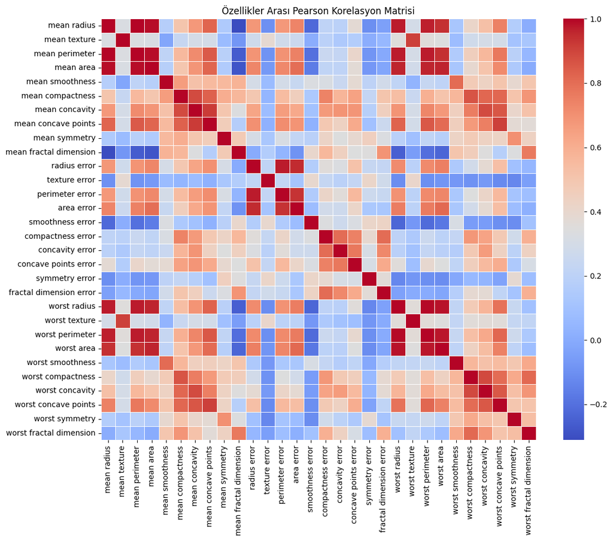

```
En yüksek korelasyonlu 3 özellik çifti (mutlak korelasyon):

mean radius   mean perimeter     0.997855
worst radius  worst perimeter    0.993708
mean radius   mean area          0.987357
dtype: float64
```

```python
# 3.2 Korelasyon Matrisi (Pearson)

import matplotlib.pyplot as plt
import seaborn as sns

corr_matrix = X.corr(method="pearson")

plt.figure(figsize=(12, 10))
sns.heatmap(corr_matrix, cmap="coolwarm", linewidths=0.5)
plt.title("Özellikler Arası Pearson Korelasyon Matrisi")
plt.tight_layout()
plt.show()

# En yüksek 3 korelasyon çifti (mutlak değere göre)
corr_abs = corr_matrix.abs()
mask = np.triu(np.ones_like(corr_abs, dtype=bool), k=1)
corr_pairs = corr_abs.where(mask).stack()
top3_corr = corr_pairs.sort_values(ascending=False).head(3)

print("\nEn yüksek korelasyonlu 3 özellik çifti (mutlak korelasyon):\n")
print(top3_corr)
```

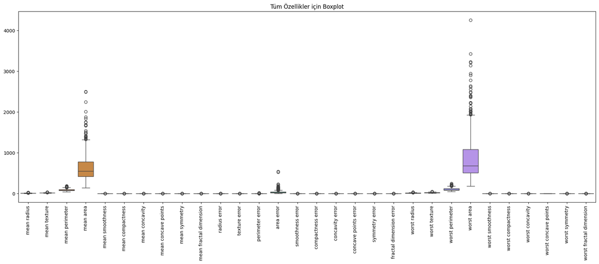

```python
# 3.3 Tüm özellikler için boxplot

plt.figure(figsize=(18, 8))
sns.boxplot(data=X)
plt.xticks(rotation=90)
plt.title("Tüm Özellikler için Boxplot")
plt.tight_layout()
plt.show()
```

```python
# 4. Veri Ölçeklendirme (StandardScaler)

from sklearn.preprocessing import StandardScaler

scaler = StandardScaler()
X_scaled_array = scaler.fit_transform(X)

X_scaled = pd.DataFrame(X_scaled_array, columns=X.columns)

print("Ölçeklendirilmiş verinin ilk 5 satırı:")
display(X_scaled.head())
```

```
Ölçeklendirilmiş verinin ilk 5 satırı:
```

|  | mean radius | mean texture | mean perimeter | mean area | mean smoothness | mean compactness | mean concavity | mean concave points | mean symmetry | mean fractal dimension | ... | worst radius | worst texture | worst perimeter | worst area | worst smoothness | worst compactness | worst concavity | worst concave points | worst symmetry | worst fractal dimension |
| --- | --- | --- | --- | --- | --- | --- | --- | --- | --- | --- | --- | --- | --- | --- | --- | --- | --- | --- | --- | --- | --- |
| 0 | 1.097064 | -2.073335 | 1.269934 | 0.984375 | 1.568466 | 3.283515 | 2.652874 | 2.532475 | 2.217515 | 2.255747 | ... | 1.886690 | -1.359293 | 2.303601 | 2.001237 | 1.307686 | 2.616665 | 2.109526 | 2.296076 | 2.750622 | 1.937015 |
| 1 | 1.829821 | -0.353632 | 1.685955 | 1.908708 | -0.826962 | -0.487072 | -0.023846 | 0.548144 | 0.001392 | -0.868652 | ... | 1.805927 | -0.369203 | 1.535126 | 1.890489 | -0.375612 | -0.430444 | -0.146749 | 1.087084 | -0.243890 | 0.281190 |
| 2 | 1.579888 | 0.456187 | 1.566503 | 1.558884 | 0.942210 | 1.052926 | 1.363478 | 2.037231 | 0.939685 | -0.398008 | ... | 1.511870 | -0.023974 | 1.347475 | 1.456285 | 0.527407 | 1.082932 | 0.854974 | 1.955000 | 1.152255 | 0.201391 |
| 3 | -0.768909 | 0.253732 | -0.592687 | -0.764464 | 3.283553 | 3.402909 | 1.915897 | 1.451707 | 2.867383 | 4.910919 | ... | -0.281464 | 0.133984 | -0.249939 | -0.550021 | 3.394275 | 3.893397 | 1.989588 | 2.175786 | 6.046041 | 4.935010 |
| 4 | 1.750297 | -1.151816 | 1.776573 | 1.826229 | 0.280372 | 0.539340 | 1.371011 | 1.428493 | -0.009560 | -0.562450 | ... | 1.298575 | -1.466770 | 1.338539 | 1.220724 | 0.220556 | -0.313395 | 0.613179 | 0.729259 | -0.868353 | -0.397100 |

5 rows × 30 columns

```python
# 5. Veri Setinin Bölünmesi
from sklearn.model_selection import train_test_split

# Önce %20 test, %80 train+val
X_train_val, X_test, y_train_val, y_test = train_test_split(
    X_scaled, y, test_size=0.20, random_state=42, stratify=y
)

# Train+val içinden %12.5'i validation olacak şekilde bölersek:
# 0.8 * 0.125 = 0.10 -> %10 validation
X_train, X_val, y_train, y_val = train_test_split(
    X_train_val, y_train_val, test_size=0.125, random_state=42, stratify=y_train_val
)

print("Eğitim seti boyutu   :", X_train.shape[0])
print("Validation seti boyutu:", X_val.shape[0])
print("Test seti boyutu      :", X_test.shape[0])
```

```
Eğitim seti boyutu   : 398
Validation seti boyutu: 57
Test seti boyutu      : 114
```

```python
# 6. Farklı MLP Modellerinin Kurulması

from sklearn.neural_network import MLPClassifier

models = {
    "Model 1 - Basit": MLPClassifier(
        hidden_layer_sizes=(16,),
        activation="relu",
        learning_rate_init=0.001,
        max_iter=500,
        random_state=42
    ),
    "Model 2 - Orta": MLPClassifier(
        hidden_layer_sizes=(32, 16),
        activation="relu",
        learning_rate_init=0.005,
        max_iter=500,
        random_state=42
    ),
    "Model 3 - Geniş": MLPClassifier(
        hidden_layer_sizes=(64, 64),
        activation="tanh",
        learning_rate_init=0.001,
        max_iter=500,
        random_state=42
    ),
    "Model 4 - Derin": MLPClassifier(
        hidden_layer_sizes=(128, 64, 32),
        activation="relu",
        learning_rate_init=0.0005,
        max_iter=500,
        random_state=42
    ),
    "Model 5 - Düşük LR": MLPClassifier(
        hidden_layer_sizes=(32,),
        activation="relu",
        learning_rate_init=0.0001,
        max_iter=500,
        random_state=42
    )
}

print("Toplam model sayısı:", len(models))
list(models.keys())
```

```
Toplam model sayısı: 5
```

```
['Model 1 - Basit',
 'Model 2 - Orta',
 'Model 3 - Geniş',
 'Model 4 - Derin',
 'Model 5 - Düşük LR']
```

```python
# 7. Validation Performanslarının Ölçülmesi

from sklearn.metrics import (
    accuracy_score,
    precision_score,
    recall_score,
    f1_score,
    roc_auc_score
)

val_results = []
trained_models = {}

for name, model in models.items():
    print(f"\n{name} eğitiliyor...")
    model.fit(X_train, y_train)
    trained_models[name] = model

    y_val_pred = model.predict(X_val)
    y_val_proba = model.predict_proba(X_val)[:, 1]

    acc = accuracy_score(y_val, y_val_pred)
    prec = precision_score(y_val, y_val_pred)
    rec = recall_score(y_val, y_val_pred)
    f1 = f1_score(y_val, y_val_pred)
    roc_auc = roc_auc_score(y_val, y_val_proba)

    val_results.append({
        "Model": name,
        "Accuracy": acc,
        "Precision": prec,
        "Recall": rec,
        "F1-Score": f1,
        "ROC-AUC": roc_auc
    })

val_results_df = pd.DataFrame(val_results)
print("\nValidation Sonuç Tablosu:\n")
display(val_results_df.sort_values(by="F1-Score", ascending=False))
```

```
Model 1 - Basit eğitiliyor...

Model 2 - Orta eğitiliyor...

Model 3 - Geniş eğitiliyor...

Model 4 - Derin eğitiliyor...

Model 5 - Düşük LR eğitiliyor...

Validation Sonuç Tablosu:
```

|  | Model | Accuracy | Precision | Recall | F1-Score | ROC-AUC |
| --- | --- | --- | --- | --- | --- | --- |
| 0 | Model 1 - Basit | 0.964912 | 0.947368 | 1.000000 | 0.972973 | 0.993386 |
| 3 | Model 4 - Derin | 0.964912 | 0.947368 | 1.000000 | 0.972973 | 0.989418 |
| 1 | Model 2 - Orta | 0.964912 | 0.972222 | 0.972222 | 0.972222 | 0.993386 |
| 2 | Model 3 - Geniş | 0.947368 | 0.945946 | 0.972222 | 0.958904 | 0.994709 |
| 4 | Model 5 - Düşük LR | 0.947368 | 0.945946 | 0.972222 | 0.958904 | 0.992063 |

```python
# 8. En İyi Modelin Seçilmesi (F1-Score'a göre)

val_results_sorted = val_results_df.sort_values(by="F1-Score", ascending=False)
best_row = val_results_sorted.iloc[0]
best_model_name = best_row["Model"]
best_model = trained_models[best_model_name]

print("En iyi model (validation F1-Score'a göre):", best_model_name)
display(best_row)
```

```
En iyi model (validation F1-Score'a göre): Model 1 - Basit
```

|  | 0 |
| --- | --- |
| Model | Model 1 - Basit |
| Accuracy | 0.964912 |
| Precision | 0.947368 |
| Recall | 1.0 |
| F1-Score | 0.972973 |
| ROC-AUC | 0.993386 |

**dtype:** object

```python
# 8.1 Test Seti performansı (En iyi model için)

y_test_pred = best_model.predict(X_test)
y_test_proba = best_model.predict_proba(X_test)[:, 1]

test_acc = accuracy_score(y_test, y_test_pred)
test_prec = precision_score(y_test, y_test_pred)
test_rec = recall_score(y_test, y_test_pred)
test_f1 = f1_score(y_test, y_test_pred)
test_roc_auc = roc_auc_score(y_test, y_test_proba)

print("Test Seti Performansı:")
print(f"Accuracy : {test_acc:.4f}")
print(f"Precision: {test_prec:.4f}")
print(f"Recall   : {test_rec:.4f}")
print(f"F1-Score : {test_f1:.4f}")
print(f"ROC-AUC  : {test_roc_auc:.4f}")
```

```
Test Seti Performansı:
Accuracy : 0.9474
Precision: 0.9714
Recall   : 0.9444
F1-Score : 0.9577
ROC-AUC  : 0.9904
```

```python
# 8.1.1 Tüm Modellerin Test Seti Üzerindeki Performansları

from sklearn.metrics import (
    accuracy_score,
    precision_score,
    recall_score,
    f1_score,
    roc_auc_score
)

test_results = []

for name, model in trained_models.items():
    y_test_pred = model.predict(X_test)
    y_test_proba = model.predict_proba(X_test)[:, 1]

    acc = accuracy_score(y_test, y_test_pred)
    prec = precision_score(y_test, y_test_pred)
    rec = recall_score(y_test, y_test_pred)
    f1 = f1_score(y_test, y_test_pred)
    roc_auc = roc_auc_score(y_test, y_test_proba)

    test_results.append({
        "Model": name,
        "Accuracy": acc,
        "Precision": prec,
        "Recall": rec,
        "F1-Score": f1,
        "ROC-AUC": roc_auc
    })

test_results_df = pd.DataFrame(test_results)
print("Tüm modeller için TEST seti performansları:\n")
display(test_results_df.sort_values(by="F1-Score", ascending=False))
```

```
Tüm modeller için TEST seti performansları:
```

|  | Model | Accuracy | Precision | Recall | F1-Score | ROC-AUC |
| --- | --- | --- | --- | --- | --- | --- |
| 2 | Model 3 - Geniş | 0.964912 | 0.972222 | 0.972222 | 0.972222 | 0.994048 |
| 1 | Model 2 - Orta | 0.964912 | 0.985714 | 0.958333 | 0.971831 | 0.989749 |
| 3 | Model 4 - Derin | 0.956140 | 0.985507 | 0.944444 | 0.964539 | 0.993056 |
| 0 | Model 1 - Basit | 0.947368 | 0.971429 | 0.944444 | 0.957746 | 0.990410 |
| 4 | Model 5 - Düşük LR | 0.929825 | 0.932432 | 0.958333 | 0.945205 | 0.991733 |

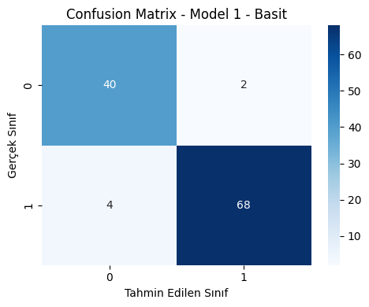

```python
# 8.2 Confusion Matrix (Isı Haritası - En iyi Model için)

from sklearn.metrics import confusion_matrix

cm = confusion_matrix(y_test, y_test_pred)

plt.figure(figsize=(5, 4))
sns.heatmap(cm, annot=True, fmt="d", cmap="Blues")
plt.xlabel("Tahmin Edilen Sınıf")
plt.ylabel("Gerçek Sınıf")
plt.title(f"Confusion Matrix - {best_model_name}")
plt.tight_layout()
plt.show()
```

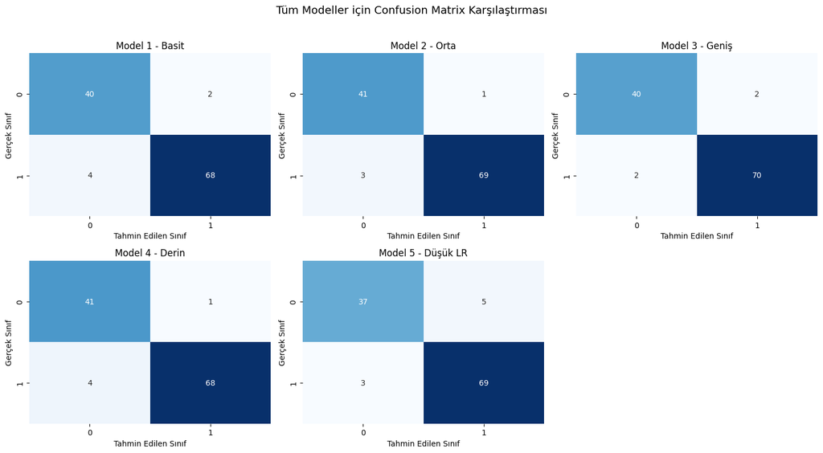

```python
# 8.2.1 Tüm Modeller için Confusion Matrix Görselleştirmesi

from sklearn.metrics import confusion_matrix
import matplotlib.pyplot as plt
import seaborn as sns
import numpy as np

model_names = list(trained_models.keys())
n_models = len(model_names)

# Maksimum 6 model için 2x3 grid; bizde 5 model var, ideal
cols = 3
rows = int(np.ceil(n_models / cols))

plt.figure(figsize=(5 * cols, 4 * rows))

for idx, name in enumerate(model_names):
    model = trained_models[name]
    y_test_pred = model.predict(X_test)
    cm = confusion_matrix(y_test, y_test_pred)

    ax = plt.subplot(rows, cols, idx + 1)
    sns.heatmap(cm, annot=True, fmt="d", cmap="Blues", cbar=False, ax=ax)
    ax.set_title(name)
    ax.set_xlabel("Tahmin Edilen Sınıf")
    ax.set_ylabel("Gerçek Sınıf")

plt.suptitle("Tüm Modeller için Confusion Matrix Karşılaştırması", y=1.02, fontsize=14)
plt.tight_layout()
plt.show()
```

[figure not shown]

```
Farklı eşik değerlerinde Precision / Recall:
Eşik = 0.3 --> Precision: 0.935, Recall: 1.000
Eşik = 0.5 --> Precision: 0.932, Recall: 0.958
Eşik = 0.7 --> Precision: 0.985, Recall: 0.903
```

```python
# 8.3 En iyi Model için ROC Eğrisi
from sklearn.metrics import roc_curve

fpr, tpr, thresholds = roc_curve(y_test, y_test_proba)

plt.figure(figsize=(6, 5))
plt.plot(fpr, tpr, label=f"ROC eğrisi (AUC = {test_roc_auc:.3f})")
plt.plot([0, 1], [0, 1], linestyle="--", label="Rastgele Sınıflandırıcı")
plt.xlabel("False Positive Rate (Yanlış Pozitif Oranı)")
plt.ylabel("True Positive Rate (Doğru Pozitif Oranı)")
plt.title(f"ROC Eğrisi - {best_model_name}")
plt.legend()
plt.grid(True)
plt.tight_layout()
plt.show()

# Farklı eşik değerlerinde Precision / Recall analizi
thresholds_to_check = [0.3, 0.5, 0.7]
print("\nFarklı eşik değerlerinde Precision / Recall:")
for thr in thresholds_to_check:
    y_thr = (y_test_proba >= thr).astype(int)
    prec_thr = precision_score(y_test, y_thr)
    rec_thr = recall_score(y_test, y_thr)
    print(f"Eşik = {thr:.1f} --> Precision: {prec_thr:.3f}, Recall: {rec_thr:.3f}")
```

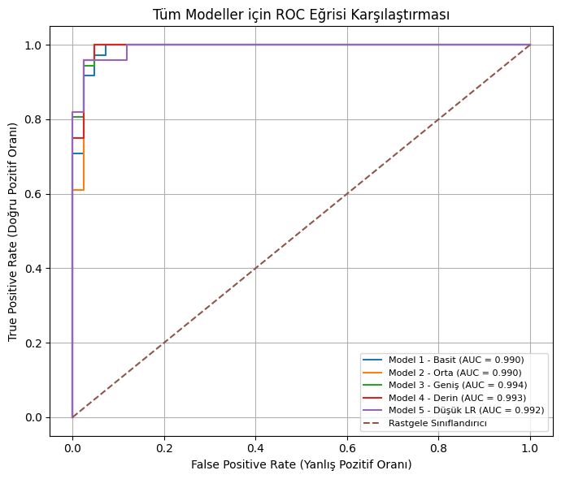

```python
# 8.3.1 Tüm Modeller için ROC Eğrisi Karşılaştırması

from sklearn.metrics import roc_curve, roc_auc_score
import matplotlib.pyplot as plt

plt.figure(figsize=(7, 6))

for name, model in trained_models.items():
    y_test_proba = model.predict_proba(X_test)[:, 1]
    fpr, tpr, _ = roc_curve(y_test, y_test_proba)
    auc_val = roc_auc_score(y_test, y_test_proba)

    plt.plot(fpr, tpr, label=f"{name} (AUC = {auc_val:.3f})")

# Rastgele sınıflandırıcı referansı
plt.plot([0, 1], [0, 1], linestyle="--", label="Rastgele Sınıflandırıcı")

plt.xlabel("False Positive Rate (Yanlış Pozitif Oranı)")
plt.ylabel("True Positive Rate (Doğru Pozitif Oranı)")
plt.title("Tüm Modeller için ROC Eğrisi Karşılaştırması")
plt.legend(fontsize=8)
plt.grid(True)
plt.tight_layout()
plt.show()
```

```python
# 8.3.2 - Farklı eşik değerlerinde tüm modeller için Precision / Recall

from sklearn.metrics import precision_score, recall_score

thresholds_to_check = [0.3, 0.5, 0.7]
threshold_results = []

for name, model in trained_models.items():
    y_test_proba = model.predict_proba(X_test)[:, 1]

    for thr in thresholds_to_check:
        y_thr = (y_test_proba >= thr).astype(int)
        prec_thr = precision_score(y_test, y_thr)
        rec_thr = recall_score(y_test, y_thr)

        threshold_results.append({
            "Model": name,
            "Eşik": thr,
            "Precision": prec_thr,
            "Recall": rec_thr
        })

threshold_results_df = pd.DataFrame(threshold_results)

print("Tüm modeller ve farklı eşik değerlerinde Precision / Recall değerleri:\n")
display(threshold_results_df.pivot_table(
    index=["Model", "Eşik"],
    values=["Precision", "Recall"]
))
```

```
Tüm modeller ve farklı eşik değerlerinde Precision / Recall değerleri:
```

| Model | Eşik | Precision | Recall |
| --- | --- | --- | --- |
| Model 1 - Basit | 0.3 | 0.960000 | 1.000000 |
|  | 0.5 | 0.971429 | 0.944444 |
|  | 0.7 | 0.985075 | 0.916667 |
| Model 2 - Orta | 0.3 | 0.985714 | 0.958333 |
|  | 0.5 | 0.985714 | 0.958333 |
|  | 0.7 | 0.985294 | 0.930556 |
| Model 3 - Geniş | 0.3 | 0.972603 | 0.986111 |
|  | 0.5 | 0.972222 | 0.972222 |
|  | 0.7 | 0.971831 | 0.958333 |
| Model 4 - Derin | 0.3 | 0.972603 | 0.986111 |
|  | 0.5 | 0.985507 | 0.944444 |
|  | 0.7 | 0.985075 | 0.916667 |
| Model 5 - Düşük LR | 0.3 | 0.935065 | 1.000000 |
|  | 0.5 | 0.932432 | 0.958333 |
|  | 0.7 | 0.984848 | 0.902778 |

```python
!pip install optuna shap --quiet
```

```
   ━━━━━━━━━━━━━━━━━━━━━━━━━━━━━━━━━━━━━━━━ 404.7/404.7 kB 6.6 MB/s eta 0:00:00
```

```python
import optuna
from sklearn.neural_network import MLPClassifier
from sklearn.metrics import accuracy_score, precision_score, recall_score, f1_score, roc_auc_score
```

```python
# Tüm trial loglarını saklamak için global liste
optuna_trial_logs = []
```

```python
# 9.1 Optuna Objective Fonksiyonu
import optuna
from sklearn.neural_network import MLPClassifier
from sklearn.metrics import accuracy_score, precision_score, recall_score, f1_score, roc_auc_score

optuna.logging.set_verbosity(optuna.logging.WARNING)  # Colab ekranını temiz tutmak için

def objective(trial):
    # 9.2 Güncel Optuna API ile parametreler
    n_hidden1 = trial.suggest_int("hidden_layer_1", 16, 256)
    n_hidden2 = trial.suggest_int("hidden_layer_2", 8, 128)
    hidden_layer_sizes = (n_hidden1, n_hidden2)

    # 🔥 GÜNCEL Optuna API
    learning_rate_init = trial.suggest_float(
        "learning_rate_init", 1e-5, 1e-1, log=True
    )
    alpha = trial.suggest_float(
        "alpha", 1e-6, 1e-2, log=True
    )

    activation = trial.suggest_categorical("activation", ["relu", "tanh"])
    solver = trial.suggest_categorical("solver", ["adam", "sgd"])
    batch_size = trial.suggest_categorical("batch_size", [16, 32, 64, 128])

    # MLP Modeli
    model = MLPClassifier(
        hidden_layer_sizes=hidden_layer_sizes,
        activation=activation,
        learning_rate_init=learning_rate_init,
        alpha=alpha,
        solver=solver,
        batch_size=batch_size,
        max_iter=300,
        random_state=42
    )

    # Eğitim
    model.fit(X_train, y_train)

    # Validation Tahmin
    y_val_pred = model.predict(X_val)
    y_val_proba = model.predict_proba(X_val)[:, 1]

    # Metrikler
    acc = accuracy_score(y_val, y_val_pred)
    prec = precision_score(y_val, y_val_pred)
    rec = recall_score(y_val, y_val_pred)
    f1 = f1_score(y_val, y_val_pred)
    roc_auc = roc_auc_score(y_val, y_val_proba)

    # Trial loglarının kaydedilmesi
    log_entry = {
        "trial_number": trial.number,
        "hidden_layer_1": n_hidden1,
        "hidden_layer_2": n_hidden2,
        "learning_rate_init": learning_rate_init,
        "alpha": alpha,
        "activation": activation,
        "solver": solver,
        "batch_size": batch_size,
        "val_accuracy": acc,
        "val_precision": prec,
        "val_recall": rec,
        "val_f1": f1,
        "val_roc_auc": roc_auc
    }
    optuna_trial_logs.append(log_entry)

    # Optuna içi kullanıcı metriği
    trial.set_user_attr("val_f1", f1)

    # Objective için geri dönüş (F1 optimizasyonu)
    return f1
```

```python
# Trial = 10 için
study = optuna.create_study(
    study_name="mlp_breast_cancer_optuna_test",
    direction="maximize"
)

study.optimize(objective, n_trials=10, show_progress_bar=True)

print("10 Trial Bitti.")
```

```
10 Trial Bitti.
```

```python
# Trial = 10 için Sonuçlar
optuna_logs_df = pd.DataFrame(optuna_trial_logs)

print("İlk 10 denemenin logları (ilk 5 satır):")
display(optuna_logs_df.head())

print("\nEn iyi 10 deneme (F1-skoruna göre):")
display(
    optuna_logs_df.sort_values(by="val_f1", ascending=False).head(10)
)
```

```
İlk 10 denemenin logları (ilk 5 satır):
```

|  | trial_number | hidden_layer_1 | hidden_layer_2 | learning_rate_init | alpha | activation | solver | batch_size | val_accuracy | val_precision | val_recall | val_f1 | val_roc_auc |
| --- | --- | --- | --- | --- | --- | --- | --- | --- | --- | --- | --- | --- | --- |
| 0 | 0 | 181 | 71 | 0.000025 | 0.002664 | relu | adam | 64 | 0.964912 | 0.972222 | 0.972222 | 0.972222 | 0.993386 |
| 1 | 1 | 46 | 116 | 0.000080 | 0.000952 | tanh | sgd | 16 | 0.929825 | 0.944444 | 0.944444 | 0.944444 | 0.990741 |
| 2 | 2 | 58 | 66 | 0.016511 | 0.000094 | relu | adam | 16 | 0.947368 | 0.971429 | 0.944444 | 0.957746 | 0.992063 |
| 3 | 3 | 174 | 18 | 0.000045 | 0.000009 | relu | sgd | 64 | 0.877193 | 0.853659 | 0.972222 | 0.909091 | 0.972222 |
| 4 | 4 | 256 | 100 | 0.088002 | 0.000014 | tanh | sgd | 16 | 0.964912 | 0.972222 | 0.972222 | 0.972222 | 0.993386 |

```
En iyi 10 deneme (F1-skoruna göre):
```

|  | trial_number | hidden_layer_1 | hidden_layer_2 | learning_rate_init | alpha | activation | solver | batch_size | val_accuracy | val_precision | val_recall | val_f1 | val_roc_auc |
| --- | --- | --- | --- | --- | --- | --- | --- | --- | --- | --- | --- | --- | --- |
| 40 | 30 | 83 | 49 | 0.004321 | 0.000900 | tanh | adam | 64 | 0.982456 | 0.972973 | 1.0 | 0.986301 | 0.996032 |
| 16 | 6 | 62 | 85 | 0.001362 | 0.000081 | relu | adam | 64 | 0.982456 | 0.972973 | 1.0 | 0.986301 | 0.992063 |
| 74 | 64 | 112 | 107 | 0.006212 | 0.000008 | relu | adam | 16 | 0.982456 | 0.972973 | 1.0 | 0.986301 | 0.992063 |
| 77 | 67 | 87 | 89 | 0.038588 | 0.000002 | relu | adam | 64 | 0.982456 | 0.972973 | 1.0 | 0.986301 | 0.994709 |
| 81 | 71 | 109 | 107 | 0.006853 | 0.000006 | relu | adam | 16 | 0.982456 | 0.972973 | 1.0 | 0.986301 | 0.989418 |
| 73 | 63 | 111 | 108 | 0.005751 | 0.000004 | relu | adam | 16 | 0.982456 | 0.972973 | 1.0 | 0.986301 | 0.994709 |
| 61 | 51 | 76 | 95 | 0.006416 | 0.000047 | relu | adam | 16 | 0.982456 | 0.972973 | 1.0 | 0.986301 | 0.994709 |
| 62 | 52 | 72 | 98 | 0.004756 | 0.000007 | relu | adam | 16 | 0.982456 | 0.972973 | 1.0 | 0.986301 | 0.992063 |
| 65 | 55 | 30 | 102 | 0.007895 | 0.000004 | relu | adam | 16 | 0.982456 | 0.972973 | 1.0 | 0.986301 | 0.996032 |
| 43 | 33 | 83 | 73 | 0.003342 | 0.005650 | tanh | adam | 64 | 0.982456 | 0.972973 | 1.0 | 0.986301 | 0.996032 |

```python
# Trial = 150 için
study = optuna.create_study(
    study_name="mlp_breast_cancer_optuna_full",
    direction="maximize"
)

study.optimize(objective, n_trials=150, show_progress_bar=True)

print("150 Trial Bitti.")
```

[output not shown]

[output cut: 81 more lines]

[output not shown]

```
150 Trial Bitti.
```

```python
# Trial = 150 için Sonuçlar
optuna_logs_df = pd.DataFrame(optuna_trial_logs)

print("Toplam trial sayısı:", len(optuna_logs_df))

display(
    optuna_logs_df.sort_values(by="val_f1", ascending=False).head(20)
)
```

```
Toplam trial sayısı: 320
```

|  | trial_number | hidden_layer_1 | hidden_layer_2 | learning_rate_init | alpha | activation | solver | batch_size | val_accuracy | val_precision | val_recall | val_f1 | val_roc_auc |
| --- | --- | --- | --- | --- | --- | --- | --- | --- | --- | --- | --- | --- | --- |
| 16 | 6 | 62 | 85 | 0.001362 | 0.000081 | relu | adam | 64 | 0.982456 | 0.972973 | 1.0 | 0.986301 | 0.992063 |
| 61 | 51 | 76 | 95 | 0.006416 | 0.000047 | relu | adam | 16 | 0.982456 | 0.972973 | 1.0 | 0.986301 | 0.994709 |
| 62 | 52 | 72 | 98 | 0.004756 | 0.000007 | relu | adam | 16 | 0.982456 | 0.972973 | 1.0 | 0.986301 | 0.992063 |
| 40 | 30 | 83 | 49 | 0.004321 | 0.000900 | tanh | adam | 64 | 0.982456 | 0.972973 | 1.0 | 0.986301 | 0.996032 |
| 43 | 33 | 83 | 73 | 0.003342 | 0.005650 | tanh | adam | 64 | 0.982456 | 0.972973 | 1.0 | 0.986301 | 0.996032 |
| 81 | 71 | 109 | 107 | 0.006853 | 0.000006 | relu | adam | 16 | 0.982456 | 0.972973 | 1.0 | 0.986301 | 0.989418 |
| 73 | 63 | 111 | 108 | 0.005751 | 0.000004 | relu | adam | 16 | 0.982456 | 0.972973 | 1.0 | 0.986301 | 0.994709 |
| 74 | 64 | 112 | 107 | 0.006212 | 0.000008 | relu | adam | 16 | 0.982456 | 0.972973 | 1.0 | 0.986301 | 0.992063 |
| 270 | 100 | 113 | 60 | 0.000146 | 0.000006 | tanh | adam | 64 | 0.982456 | 0.972973 | 1.0 | 0.986301 | 0.996032 |
| 88 | 78 | 82 | 124 | 0.004387 | 0.000001 | relu | sgd | 64 | 0.982456 | 0.972973 | 1.0 | 0.986301 | 0.994709 |
| 92 | 82 | 87 | 94 | 0.028737 | 0.000063 | relu | adam | 64 | 0.982456 | 0.972973 | 1.0 | 0.986301 | 0.992063 |
| 93 | 83 | 105 | 106 | 0.048150 | 0.000007 | relu | adam | 64 | 0.982456 | 0.972973 | 1.0 | 0.986301 | 0.994709 |
| 260 | 90 | 227 | 68 | 0.000326 | 0.000033 | tanh | sgd | 128 | 0.982456 | 0.972973 | 1.0 | 0.986301 | 0.993386 |
| 65 | 55 | 30 | 102 | 0.007895 | 0.000004 | relu | adam | 16 | 0.982456 | 0.972973 | 1.0 | 0.986301 | 0.996032 |
| 77 | 67 | 87 | 89 | 0.038588 | 0.000002 | relu | adam | 64 | 0.982456 | 0.972973 | 1.0 | 0.986301 | 0.994709 |
| 152 | 142 | 31 | 88 | 0.029403 | 0.000018 | relu | adam | 16 | 0.982456 | 0.972973 | 1.0 | 0.986301 | 0.992063 |
| 158 | 148 | 64 | 81 | 0.008940 | 0.000008 | relu | sgd | 64 | 0.982456 | 0.972973 | 1.0 | 0.986301 | 0.994709 |
| 126 | 116 | 69 | 101 | 0.088636 | 0.000112 | relu | adam | 16 | 0.982456 | 0.972973 | 1.0 | 0.986301 | 0.989418 |
| 98 | 88 | 91 | 74 | 0.000495 | 0.000147 | tanh | adam | 64 | 0.982456 | 0.972973 | 1.0 | 0.986301 | 0.996032 |
| 99 | 89 | 26 | 90 | 0.012393 | 0.000019 | relu | adam | 16 | 0.982456 | 0.972973 | 1.0 | 0.986301 | 0.992063 |

```python
import shap
import numpy as np

shap.initjs()

# Background dataset (KernelExplainer için)
X_train_bg = X_train.sample(50, random_state=42)

# Validation setinden örnek seç – fazla örnek isteme hatasını önlemek için:
n_val = min(100, len(X_val))   # validation setinden max 100 al
X_val_sample = X_val.sample(n_val, random_state=42)

print(f"Validation set boyutu: {len(X_val)}")
print(f"SHAP analizi için seçilen örnek sayısı: {len(X_val_sample)}")
```

```
Validation set boyutu: 57
SHAP analizi için seçilen örnek sayısı: 57
```

```python
# 10.1.1 En iyi MLP modeli için SHAP Explainer

def best_model_predict_proba(X_array):
    # Pozitif sınıfın (1) olasılığını döndürüyoruz
    return best_model.predict_proba(X_array)[:, 1]

explainer_best = shap.KernelExplainer(best_model_predict_proba, X_train_bg)

# Uyarı: Bu adım biraz zaman alabilir (özellikle nsamples yüksekse)
shap_values_best = explainer_best.shap_values(X_val_sample, nsamples=100)
```

[output not shown]

[output cut: 173 more lines]

[output not shown]

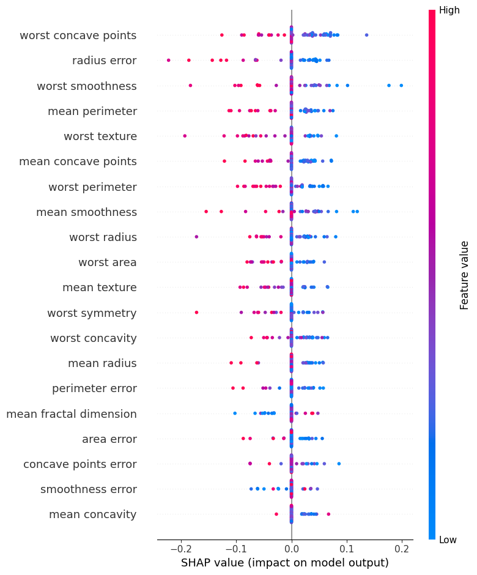

```python
# 10.1.2 summary_plot (nokta grafiği)

shap.summary_plot(
    shap_values_best,
    X_val_sample,
    feature_names=X_val_sample.columns
)
```

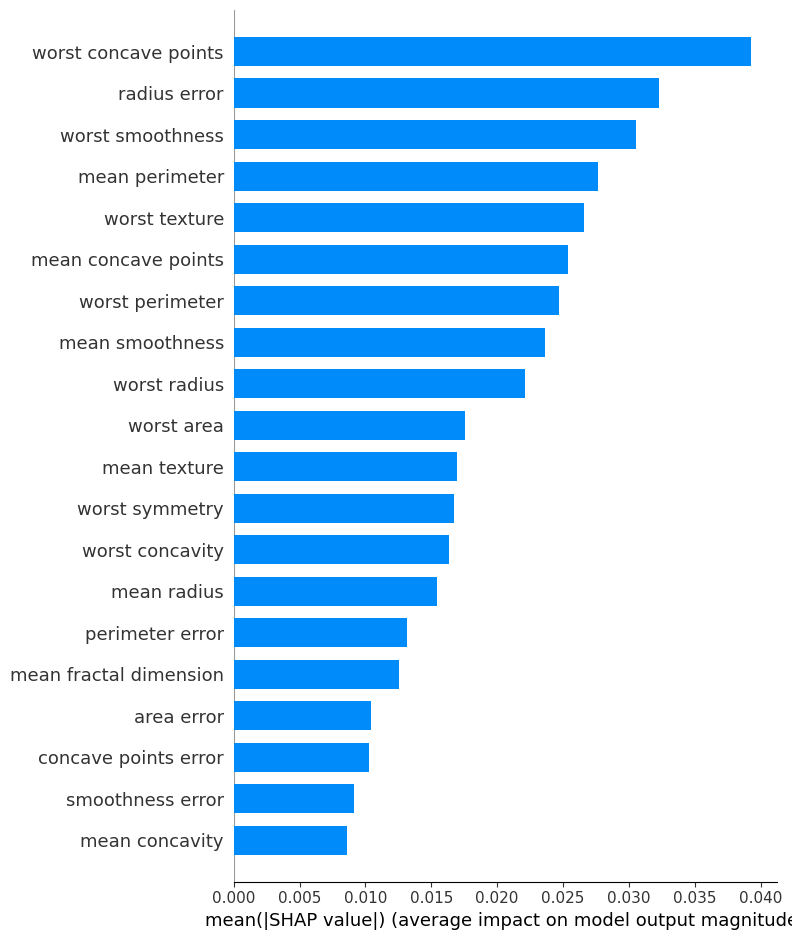

```python
# 10.1.2 bar_plot (özellik önem sıralaması)

shap.summary_plot(
    shap_values_best,
    X_val_sample,
    feature_names=X_val_sample.columns,
    plot_type="bar"
)
```

```python
# 10.2.1 Optuna en iyi trial ve modelin yeniden kurulması

best_trial = study.best_trial

print("Optuna en iyi trial parametreleri:")
for k, v in best_trial.params.items():
    print(f"{k}: {v}")

opt_hidden_layer_sizes = (
    best_trial.params["hidden_layer_1"],
    best_trial.params["hidden_layer_2"]
)

opt_activation = best_trial.params["activation"]
opt_solver = best_trial.params["solver"]
opt_lr = best_trial.params["learning_rate_init"]
opt_alpha = best_trial.params["alpha"]
opt_batch_size = best_trial.params["batch_size"]

optuna_best_model = MLPClassifier(
    hidden_layer_sizes=opt_hidden_layer_sizes,
    activation=opt_activation,
    learning_rate_init=opt_lr,
    alpha=opt_alpha,
    solver=opt_solver,
    batch_size=opt_batch_size,
    max_iter=300,
    random_state=42
)

optuna_best_model.fit(X_train, y_train)
```

```
Optuna en iyi trial parametreleri:
hidden_layer_1: 222
hidden_layer_2: 79
learning_rate_init: 0.0001222996065232356
alpha: 4.727513922056682e-06
activation: tanh
solver: adam
batch_size: 32
```

```
MLPClassifier(activation='tanh', alpha=4.727513922056682e-06, batch_size=32,
              hidden_layer_sizes=(222, 79),
              learning_rate_init=0.0001222996065232356, max_iter=300,
              random_state=42)
```

```python
from sklearn.metrics import accuracy_score, precision_score, recall_score, f1_score, roc_auc_score

# Validation
y_val_pred_opt = optuna_best_model.predict(X_val)
y_val_proba_opt = optuna_best_model.predict_proba(X_val)[:, 1]

val_acc_opt = accuracy_score(y_val, y_val_pred_opt)
val_prec_opt = precision_score(y_val, y_val_pred_opt)
val_rec_opt = recall_score(y_val, y_val_pred_opt)
val_f1_opt = f1_score(y_val, y_val_pred_opt)
val_roc_auc_opt = roc_auc_score(y_val, y_val_proba_opt)

print("\nOptuna en iyi model - Validation performansı:")
print(f"Accuracy : {val_acc_opt:.4f}")
print(f"Precision: {val_prec_opt:.4f}")
print(f"Recall   : {val_rec_opt:.4f}")
print(f"F1-Score : {val_f1_opt:.4f}")
print(f"ROC-AUC  : {val_roc_auc_opt:.4f}")
```

```
Optuna en iyi model - Validation performansı:
Accuracy : 0.9825
Precision: 0.9730
Recall   : 1.0000
F1-Score : 0.9863
ROC-AUC  : 0.9960
```

```python
# 10.2.2 Optuna en iyi model için SHAP Explainer

def optuna_model_predict_proba(X_array):
    return optuna_best_model.predict_proba(X_array)[:, 1]

explainer_optuna = shap.KernelExplainer(optuna_model_predict_proba, X_train_bg)

shap_values_optuna = explainer_optuna.shap_values(X_val_sample, nsamples=100)
```

[output not shown]

[output cut: 173 more lines]

[output not shown]

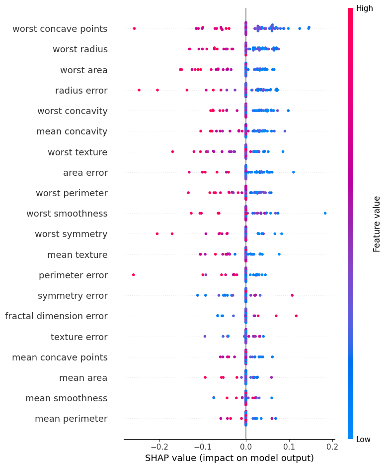

```python
# 10.2.3 summary_plot (nokta)

shap.summary_plot(
    shap_values_optuna,
    X_val_sample,
    feature_names=X_val_sample.columns
)
```

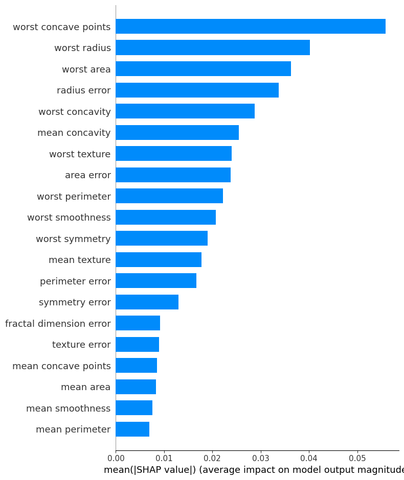

```python
# 10.2.4 bar_plot

shap.summary_plot(
    shap_values_optuna,
    X_val_sample,
    feature_names=X_val_sample.columns,
    plot_type="bar"
)
```

[figure not shown]

```python
# 10.2.5 force_plot - tek bir örnek (matplotlib ile, JS’siz)

i = 0  # örnek indeksimiz
x_instance = X_val_sample.iloc[i]

expected_value_opt = explainer_optuna.expected_value
shap_values_instance_opt = shap_values_optuna[i]

shap.force_plot(
    expected_value_opt,
    shap_values_instance_opt,
    x_instance,
    feature_names=X_val_sample.columns,
    matplotlib=True
)
```

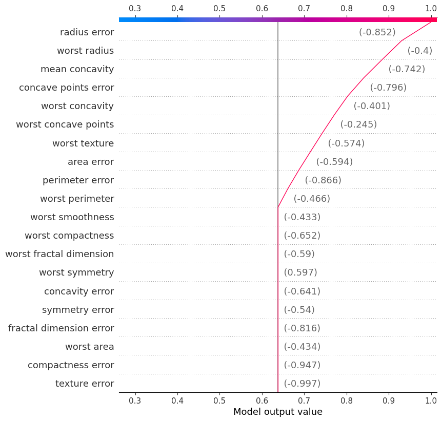

```python
# 10.2.6 decision_plot - aynı örnek için

# i ve x_instance zaten yukarıda tanımlı:
# i = 0
# x_instance = X_val_sample.iloc[i]
# shap_values_instance_opt = shap_values_optuna[i]
# expected_value_opt = explainer_optuna.expected_value

shap.decision_plot(
    expected_value_opt,
    shap_values_instance_opt,          # 1D SHAP değerleri
    x_instance.values,                # özellik değerleri -> numpy array
    feature_names=list(X_val_sample.columns),  # list'e çeviriyoruz
    show=True
)
```

```python
# Optuna trial logları DataFrame'e çevrilir
optuna_logs_df = pd.DataFrame(optuna_trial_logs)

print("Toplam trial sayısı:", len(optuna_logs_df))

print("\nValidation F1-Score'a göre en iyi 10 deneme:")
best10 = optuna_logs_df.sort_values(by="val_f1", ascending=False).head(10)
display(best10)
```

```
Toplam trial sayısı: 320

Validation F1-Score'a göre en iyi 10 deneme:
```

|  | trial_number | hidden_layer_1 | hidden_layer_2 | learning_rate_init | alpha | activation | solver | batch_size | val_accuracy | val_precision | val_recall | val_f1 | val_roc_auc |
| --- | --- | --- | --- | --- | --- | --- | --- | --- | --- | --- | --- | --- | --- |
| 16 | 6 | 62 | 85 | 0.001362 | 0.000081 | relu | adam | 64 | 0.982456 | 0.972973 | 1.0 | 0.986301 | 0.992063 |
| 61 | 51 | 76 | 95 | 0.006416 | 0.000047 | relu | adam | 16 | 0.982456 | 0.972973 | 1.0 | 0.986301 | 0.994709 |
| 62 | 52 | 72 | 98 | 0.004756 | 0.000007 | relu | adam | 16 | 0.982456 | 0.972973 | 1.0 | 0.986301 | 0.992063 |
| 40 | 30 | 83 | 49 | 0.004321 | 0.000900 | tanh | adam | 64 | 0.982456 | 0.972973 | 1.0 | 0.986301 | 0.996032 |
| 43 | 33 | 83 | 73 | 0.003342 | 0.005650 | tanh | adam | 64 | 0.982456 | 0.972973 | 1.0 | 0.986301 | 0.996032 |
| 81 | 71 | 109 | 107 | 0.006853 | 0.000006 | relu | adam | 16 | 0.982456 | 0.972973 | 1.0 | 0.986301 | 0.989418 |
| 73 | 63 | 111 | 108 | 0.005751 | 0.000004 | relu | adam | 16 | 0.982456 | 0.972973 | 1.0 | 0.986301 | 0.994709 |
| 74 | 64 | 112 | 107 | 0.006212 | 0.000008 | relu | adam | 16 | 0.982456 | 0.972973 | 1.0 | 0.986301 | 0.992063 |
| 270 | 100 | 113 | 60 | 0.000146 | 0.000006 | tanh | adam | 64 | 0.982456 | 0.972973 | 1.0 | 0.986301 | 0.996032 |
| 88 | 78 | 82 | 124 | 0.004387 | 0.000001 | relu | sgd | 64 | 0.982456 | 0.972973 | 1.0 | 0.986301 | 0.994709 |

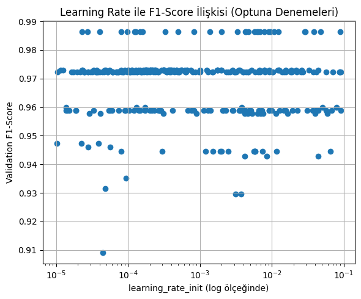

```python
#Learning Rate vs F1 Grafiği
import matplotlib.pyplot as plt

plt.figure(figsize=(6, 5))
plt.scatter(optuna_logs_df["learning_rate_init"], optuna_logs_df["val_f1"])
plt.xscale("log")
plt.xlabel("learning_rate_init (log ölçeğinde)")
plt.ylabel("Validation F1-Score")
plt.title("Learning Rate ile F1-Score İlişkisi (Optuna Denemeleri)")
plt.grid(True)
plt.tight_layout()
plt.show()
```

```python
from optuna.visualization import plot_optimization_history, plot_param_importances

# Optimizasyon sürecinde F1'in nasıl geliştiğini gösterir
fig1 = plot_optimization_history(study)
fig1.show()

# Hangi hiperparametrelerin F1 üzerinde daha etkili olduğunu gösterir
fig2 = plot_param_importances(study)
fig2.show()
```

[interactive chart not shown]

```python
# |SHAP| değerlerinin ortalamasını alarak özellik önemlerini hesaplayalım
mean_abs_shap_best = np.mean(np.abs(shap_values_best), axis=0)

shap_importance_best = pd.DataFrame({
    "özellik": X_val_sample.columns,
    "ortalama_mutlak_shap": mean_abs_shap_best
}).sort_values(by="ortalama_mutlak_shap", ascending=False)

print("En iyi MLP modeli için en önemli 10 özellik (SHAP'e göre):")
display(shap_importance_best.head(10))
```

```
En iyi MLP modeli için en önemli 10 özellik (SHAP'e göre):
```

|  | özellik | ortalama_mutlak_shap |
| --- | --- | --- |
| 27 | worst concave points | 0.039290 |
| 10 | radius error | 0.032298 |
| 24 | worst smoothness | 0.030516 |
| 2 | mean perimeter | 0.027644 |
| 21 | worst texture | 0.026564 |
| 7 | mean concave points | 0.025342 |
| 22 | worst perimeter | 0.024668 |
| 4 | mean smoothness | 0.023658 |
| 20 | worst radius | 0.022115 |
| 23 | worst area | 0.017589 |

```python
mean_abs_shap_opt = np.mean(np.abs(shap_values_optuna), axis=0)

shap_importance_opt = pd.DataFrame({
    "özellik": X_val_sample.columns,
    "ortalama_mutlak_shap": mean_abs_shap_opt
}).sort_values(by="ortalama_mutlak_shap", ascending=False)

print("Optuna en iyi modeli için en önemli 10 özellik (SHAP'e göre):")
display(shap_importance_opt.head(10))
```

```
Optuna en iyi modeli için en önemli 10 özellik (SHAP'e göre):
```

|  | özellik | ortalama_mutlak_shap |
| --- | --- | --- |
| 27 | worst concave points | 0.055829 |
| 20 | worst radius | 0.040174 |
| 23 | worst area | 0.036315 |
| 10 | radius error | 0.033699 |
| 26 | worst concavity | 0.028775 |
| 6 | mean concavity | 0.025430 |
| 21 | worst texture | 0.023986 |
| 13 | area error | 0.023778 |
| 22 | worst perimeter | 0.022180 |
| 24 | worst smoothness | 0.020698 |

```python
# İki tabloyu birleştirip karşılaştırma tablosu yapalım
merge_importance = shap_importance_best.merge(
    shap_importance_opt,
    on="özellik",
    suffixes=("_best_model", "_optuna_model")
)

# Ortalamalara göre fark da göstersin
merge_importance["fark_optuna_eksi_best"] = (
    merge_importance["ortalama_mutlak_shap_optuna_model"]
    - merge_importance["ortalama_mutlak_shap_best_model"]
)

print("İki modelin SHAP önemlerinin karşılaştırılması (ilk 15 satır):")
display(
    merge_importance.sort_values(
        by="ortalama_mutlak_shap_optuna_model",
        ascending=False
    ).head(15)
)
```

```
İki modelin SHAP önemlerinin karşılaştırılması (ilk 15 satır):
```

|  | özellik | ortalama_mutlak_shap_best_model | ortalama_mutlak_shap_optuna_model | fark_optuna_eksi_best |
| --- | --- | --- | --- | --- |
| 0 | worst concave points | 0.039290 | 0.055829 | 0.016539 |
| 8 | worst radius | 0.022115 | 0.040174 | 0.018059 |
| 9 | worst area | 0.017589 | 0.036315 | 0.018726 |
| 1 | radius error | 0.032298 | 0.033699 | 0.001401 |
| 12 | worst concavity | 0.016375 | 0.028775 | 0.012400 |
| 19 | mean concavity | 0.008586 | 0.025430 | 0.016844 |
| 4 | worst texture | 0.026564 | 0.023986 | -0.002578 |
| 16 | area error | 0.010419 | 0.023778 | 0.013359 |
| 6 | worst perimeter | 0.024668 | 0.022180 | -0.002488 |
| 2 | worst smoothness | 0.030516 | 0.020698 | -0.009817 |
| 11 | worst symmetry | 0.016755 | 0.019043 | 0.002288 |
| 10 | mean texture | 0.016930 | 0.017794 | 0.000864 |
| 14 | perimeter error | 0.013190 | 0.016690 | 0.003500 |
| 23 | symmetry error | 0.006496 | 0.012942 | 0.006445 |
| 25 | fractal dimension error | 0.005475 | 0.009180 | 0.003705 |

# 1. Veri Seti Hazırlığı ve Kalite Kontrolleri

**1.1 Veri Setinin Yüklenmesi**

Colab ortamına yüklenen breast_cancer_wisconsin.csv dosyası Pandas ile DataFrame’e aktarılmıştır. Bağımsız değişkenler X, bağımlı değişken (hedef sınıf) y olarak ayrılmıştır.

Toplam örnek sayısı: 569 Toplam özellik sayısı: 30

**1.2 Eksik Değer Analizi**

Notebook çıktısına göre veri setinde hiçbir sütunda eksik değer yoktur (0 missing). Bu, veri setinin temiz olduğunu ve ek imputasyon gerektirmediğini göstermektedir.

**1.3 Aykırı Değer Analizi**

IQR yöntemine göre toplam 608 aykırı değer tespit edilmiştir. Bu aykırı değerler özellikle aşağıdaki sütunlarda yoğunlaşmıştır:

Aykırı değerlerin tespiti doğru yapılsa da sınıflandırma problemlerinde MLP, ölçeklendirme sonrası bu değerlerden etkilenmediği için veri dışlama işlemine gidilmemiştir.

**1.4 Veri Tipleri**

Tüm özellikler float64, hedef sütunu int64 türündedir. Sayısal/kategorik dağılım veri seti için beklenen yapıdadır.

# 2. Keşifsel Veri Analizi (EDA)

**2.1 Temel İstatistikler**

Her özellik için mean, median, std, min–max, Q1–Q3 değerleri hesaplanmıştır. En yüksek varyanslı özellikler:

mean area

worst area

**2.2 Korelasyon Analizi**

Pearson korelasyon sonuçlarına göre en yüksek ilişkili 3 özellik çifti:

mean radius – mean perimeter: 0.9979

worst radius – worst perimeter: 0.9937

mean radius – mean area: 0.9874

Bu yüksek korelasyon değerleri, tümör boyutuna bağlı metriklerin birbirini güçlü şekilde temsil ettiğini göstermektedir.

**2.3 Boxplot Analizleri**

Boxplotlara göre tümör büyüklüğü ile ilişkili özelliklerde çok sayıda aykırı değer görülmüştür. Bu durum, kötü huylu (malignant) tümörlerde değerlerin geniş aralıkta değişmesinden kaynaklanmaktadır.

# 3. Veri Ölçeklendirme

Tüm özellikler StandardScaler ile ölçeklendirilmiştir. Hem MLP hem de Optuna modelleri bu ölçekli veriler üzerine kurulmuştur.

# 4. Veri Setinin Bölünmesi

Veri seti şu şekilde bölünmüştür:

%70 Training → 398 örnek

%10 Validation → 57 örnek

%20 Test → 114 örnek

Validation seti, hem farklı MLP modellerinin performans karşılaştırmasında hem de Optuna optimizasyonunda kullanılmıştır.

# 5. Farklı MLP Modelleri ve Validation Sonuçları

Aşağıdaki beş farklı MLP mimarisi denenmiştir:

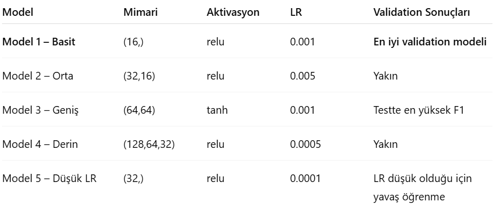

Validation sonuçlarına göre en iyi model Model 1 (Basit model) olarak belirlenmiştir.